# DoD Fixed-Price Study

Greg Sanders

Tuesday, January 13, 2015

Contracts are classified using a mix of numerical and categorical variables. While the changes in numerical variables are easy to grasp and summarize, the move from being a research and development (R&D) contract and the like to a product contract requires deliberate consideration. As an important added factor, for the fixed-price study, we are only considering information that contracting officer knew going in. This is an attempt to avoid having our independent variables influenced by contract performance. For example, a standard of 50% R&D content by value would be influenced by whether the R&D portion of the project took longer than expected.

## Studying R&D contracts in the sample.

For this study we are looking at whether a contract includes the first five phases of R&D. We are considering a variety of different criteria, but have the benefit from the fact that R&D work should consistently occur at the front end of the data.

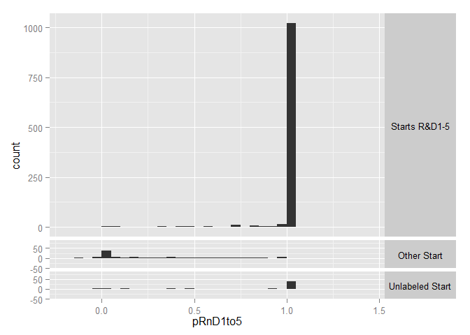

```r
require(ggplot2)
setwd("K:\\Development\\Fixed-price")
# setwd("C:\\Users\\Greg Sanders\\Documents\\Development\\Fixed-price")
contract.sample  <- read.csv(
    paste("data\\defense_contract_CSIScontractID_sample_15000_SumofObligatedAmount.csv", sep = ""),
    header = TRUE, sep = ",", dec = ".", strip.white = TRUE,
    na.strings = c("NULL","NA",""),
    stringsAsFactors = FALSE
    )

contract.sample$firstSignedDateRnD1to5 <- strptime(contract.sample$firstSignedDateRnD1to5, "%Y-%m-%d")
contract.sample$MinOfEffectiveDate <- strptime(contract.sample$MinOfEffectiveDate, "%Y-%m-%d")
contract.sample$isAnyRnD1to5 <- factor(contract.sample$isAnyRnD1to5,
                                     levels = c(0,1),
                                     labels = c("No R&D1-5","Any R&D1-5"))
contract.sample$UnmodifiedRnD1to5 <- factor(contract.sample$UnmodifiedRnD1to5,
                                          levels  = c(1,0),
                                          labels = c("Starts R&D1-5","Other Start"))
contract.sample$UnmodifiedRnD1to5 <- addNA(contract.sample$UnmodifiedRnD1to5,
                                           ifany = TRUE)

levels(contract.sample$UnmodifiedRnD1to5)[is.na(levels(contract.sample$UnmodifiedRnD1to5))]  <-  "Unlabeled Start"
contract.sample$pRnD1to5 <- contract.sample$obligatedAmountRnD1to5/contract.sample$SumofObligatedAmount
contract.sample$pRnD1to5[is.na(contract.sample$obligatedAmountRnD1to5)] <- 0
contract.sample$simplearea <- addNA(contract.sample$simplearea, ifany = TRUE)
levels(contract.sample$simplearea)[is.na(levels(contract.sample$simplearea))]  <-  "Unlabeled\nor Mixed"

ggplot(
    data = subset(contract.sample, isAnyRnD1to5 == "Any R&D1-5"),
    aes_string(x = "pRnD1to5"),
    main = "R&D(1-5) distribution by contract count"
    ) +
    geom_bar(binwidth = 0.05) +
    facet_grid( UnmodifiedRnD1to5 ~ .,
                scales = "free_y",
                space = "free_y") + scale_y_continuous(expand = c(0,50)) +
    theme(strip.text.y  = element_text(angle = 360)
          )
```

```r
fiftysens <- nrow(contract.sample[contract.sample$pRnD1to5 >= 0.5 &
                                    (contract.sample$UnmodifiedRnD1to5 == "Starts R&D1-5"), ])/
    nrow(contract.sample[contract.sample$pRnD1to5 >= 0.5, ])


fiftyspec <- nrow(contract.sample[contract.sample$pRnD1to5<0.5 &
                                    !(contract.sample$UnmodifiedRnD1to5 == "Starts R&D1-5"), ]) /
    nrow(contract.sample[contract.sample$pRnD1to5<0.5, ])

RnDsens <- nrow(contract.sample[contract.sample$simplearea == "R&D" &
                                  (contract.sample$UnmodifiedRnD1to5 == "Starts R&D1-5"), ]) /
    nrow(contract.sample[contract.sample$simplearea == "R&D", ])


RnDspec <- nrow(contract.sample[contract.sample$simplearea != "R&D" &
                                  !(contract.sample$UnmodifiedRnD1to5=="Starts R&D1-5"), ]) /
    nrow(contract.sample[contract.sample$simplearea != "R&D", ])

nrow(contract.sample[contract.sample$pRnD1to5 >= 0.5, ])
```

```
## [1] 1139
```

Based on this first analysis, it appears that labeling an R&D(1-5) contract by its first element works for at least 90% of cases.

If we assume all contracts with 50% or more R&D(1-5) content by value are true R&D(1-5) contracts then the sensitivity (or true positive rate) is 0.9455663 and the specificity (or true negative rate) is 0.9983407.

If we assume all contracts that are exclusively R&D(1-5,7), when labeled, then the sensitivity (or true positive rate) is 0.9134355 and the specificity (or true negative rate) is 0.993737.

- The biggest problem appears to be those contracts whose first entry is not labeled. However, the vast majority of those contracts are 95%-100% R&D(1-5), which should make classifying them fairly easy.
- Those contracts that start as non-R&D are consistently below 50% R&D(1-5) with a notable exception in the 95% to 100% range. Capturing those should be simple.
- Those contracts that start R&D(1-5) but have less than 50% of dollars in that category might be false positives.

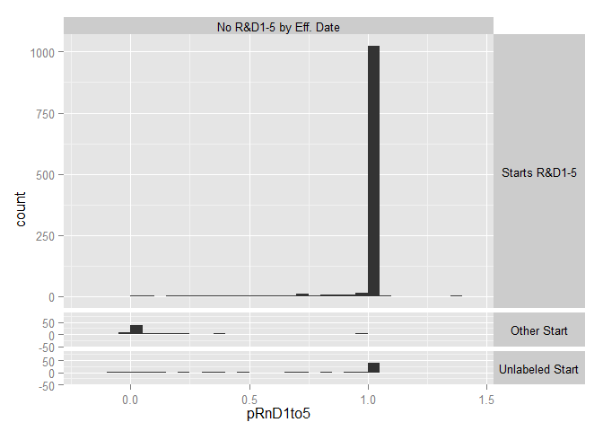

```r
contract.sample$isRnD1to5byStart <- NA
contract.sample$isRnD1to5byStart[contract.sample$firstSignedDateRnD1to5 <=
                                     contract.sample$MinOfEffectiveDate] <- TRUE
contract.sample$isRnD1to5byStart[contract.sample$firstSignedDateRnD1to5 >
                                     contract.sample$MinOfEffectiveDate] <- FALSE
contract.sample$isRnD1to5byStart[is.na(contract.sample$firstSignedDateRnD1to5)] <- FALSE
contract.sample$isRnD1to5byStart <- factor(contract.sample$isRnD1to5byStart,
                                         levels = c(TRUE,FALSE),
                                         labels = c("R&D1-5 by Eff. Date","No R&D1-5 by Eff. Date")
                                         )

ggplot(
    data=subset(contract.sample,isAnyRnD1to5 == "Any R&D1-5")
    ,aes_string(x = "pRnD1to5")
    )+geom_bar(binwidth = 0.05) + facet_grid(UnmodifiedRnD1to5~isRnD1to5byStart,
                                             scales = "free_y",
                                             space = "free_y") +
    scale_y_continuous(expand=c(0,50))+
    theme(strip.text.y = element_text(angle = 360)
          )
```

If we include all contracts that either are labeled as R&D(1-5) in their unmodified version or before their effective date, then the sensitivity of the test improves by either standard without notably reducing the specificity.

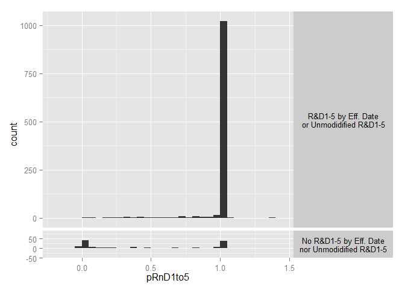

```r
contract.sample$isInitialRnD1to5 <- NA
contract.sample$isInitialRnD1to5[!(contract.sample$UnmodifiedRnD1to5 == "Starts R&D1-5" |
                                       contract.sample$isRnD1to5byStart == "R&D1-5 by Eff. Date ")] <- FALSE
contract.sample$isInitialRnD1to5[contract.sample$UnmodifiedRnD1to5 == "Starts R&D1-5"] <- TRUE
contract.sample$isInitialRnD1to5[contract.sample$isRnD1to5byStart == "R&D1-5 by Eff. Date"] <- TRUE
contract.sample$isInitialRnD1to5 <- factor(contract.sample$isInitialRnD1to5,
                                         levels = c(TRUE,FALSE),
                                         labels = c("R&D1-5 by Eff. Date\nor Unmodidified R&D1-5"
                                                    ,"No R&D1-5 by Eff. Date\nnor Unmodidified R&D1-5")
                                         )


ggplot(
    data=subset(contract.sample,isAnyRnD1to5 == "Any R&D1-5"),
    aes_string(x = "pRnD1to5"))+
    geom_bar(binwidth = 0.05)+
    facet_grid(isInitialRnD1to5~.,
               scales = "free_y",
               space = "free_y")+
    scale_y_continuous(expand = c(0,50))+
    theme(strip.text.y = element_text(angle = 360)
          )
```

```r
fiftysens <- nrow(contract.sample[contract.sample$isInitialRnD1to5 ==
                                    "R&D1-5 by Eff. Date\nor Unmodidified R&D1-5" &
                                    contract.sample$pRnD1to5 >= 0.5, ]) /
    nrow(contract.sample[contract.sample$pRnD1to5 >= 0.5, ])

fiftyspec <- nrow(contract.sample[contract.sample$isInitialRnD1to5 ==
                                    "No R&D1-5 by Eff. Date\nnor Unmodidified R&D1-5" &
                                    contract.sample$pRnD1to5<0.5, ]) /
    nrow(contract.sample[contract.sample$pRnD1to5<0.5, ])

RnDsens <- nrow(contract.sample[contract.sample$isInitialRnD1to5 ==
                                  "R&D1-5 by Eff. Date\nor Unmodidified R&D1-5" &
                                  contract.sample$simplearea == "R&D", ]) /
    nrow(contract.sample[contract.sample$simplearea == "R&D", ])


RnDspec <- nrow(contract.sample[contract.sample$isInitialRnD1to5 ==
                                  "No R&D1-5 by Eff. Date\nnor Unmodidified R&D1-5" &
                                  contract.sample$simplearea != "R&D", ]) /
    nrow(contract.sample[contract.sample$simplearea != "R&D", ])
```